# ggplot (wk5d1 homework)

```r
library(janitor)
```

|  | device | id | hours | mins | counts |
| --- | --- | --- | --- | --- | --- |
| 361 | qikbit1 | person1 | 6 | 0 | 0 |
| 362 | qikbit1 | person1 | 6 | 1 | 0 |
| 363 | qikbit1 | person1 | 6 | 2 | 0 |
| 364 | qikbit1 | person1 | 6 | 3 | 0 |
| 365 | qikbit1 | person1 | 6 | 4 | 0 |
| 366 | qikbit1 | person1 | 6 | 5 | 0 |
| 367 | qikbit1 | person1 | 6 | 6 | 0 |
| 368 | qikbit1 | person1 | 6 | 7 | 0 |
| 369 | qikbit1 | person1 | 6 | 8 | 0 |
| 370 | qikbit1 | person1 | 6 | 9 | 0 |

[output cut: 990 more lines]

# MVP

For part 1, make plots.

```r
# make custom theme
theme_kwikbit <- function(){
  theme_minimal() +
  theme(
    # modify legend and set font sizes
    legend.position = "right",
    legend.title = element_text(size = 12, family = "Arial"),
    legend.text = element_text(size = rel(0.8), family = "Arial"),
    axis.title = element_text(size = rel(0.8), family = "Arial"),
    plot.title = element_text(size = rel(1.25), family = "Arial"),
    # remove minor grid lines
    panel.grid.major.x = element_blank(),
    panel.grid.minor.x = element_blank(),
    panel.grid.minor.y = element_blank()
  )
}
```

## 2.1.1 - make plot

Take the data in the dataset qb_revenue_breakdown and make a stacked bar chart showing the sources of revenue across the two years in the dataset.

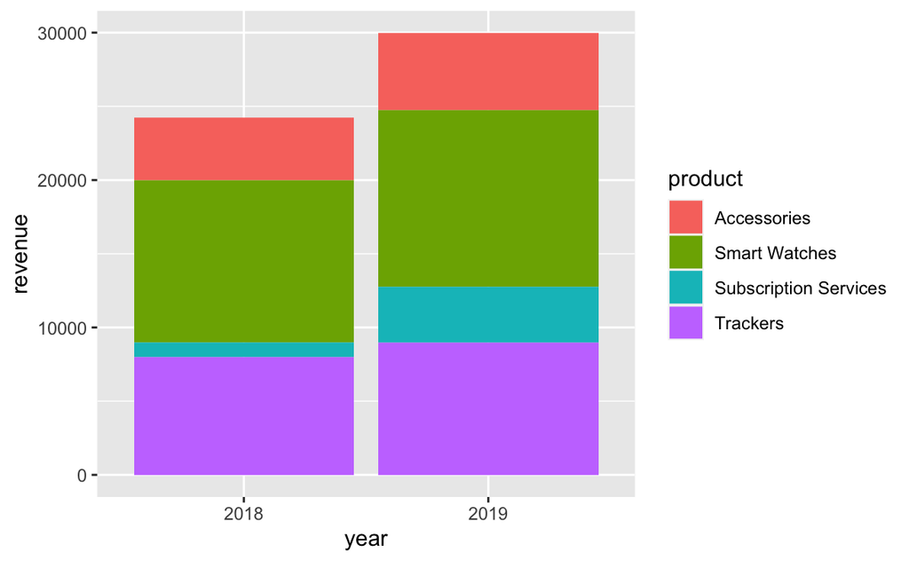

```r
ggplot(qb_revenue_breakdown) +
  aes(x = year, y = revenue, fill = product) +
  geom_col()
```

## 2.2.1 - prettify plot

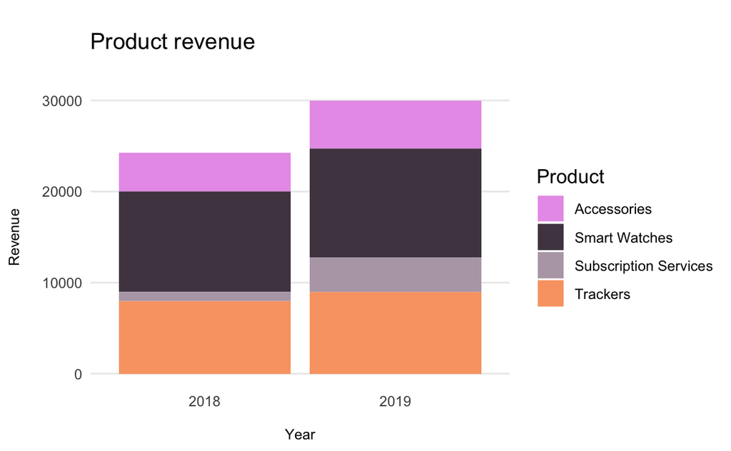

```r
ggplot(qb_revenue_breakdown) +
  aes(x = year, y = revenue, fill = product) +
  geom_col() +
  labs(
    x = "\nYear",
    y = "Revenue\n",
    title = "\nProduct revenue\n",
    fill = "Product"
  ) +
  scale_fill_manual(values = col_scheme) +
  theme_kwikbit()
```

## 2.1.2 - make plot

Make a line chart showing monthly sales of the “flagship product” - the ‘KwikBit Unit 1’ - over the last year. This data is inside qb_monthly_sales, but you will need to use filter() or subset() (base R).

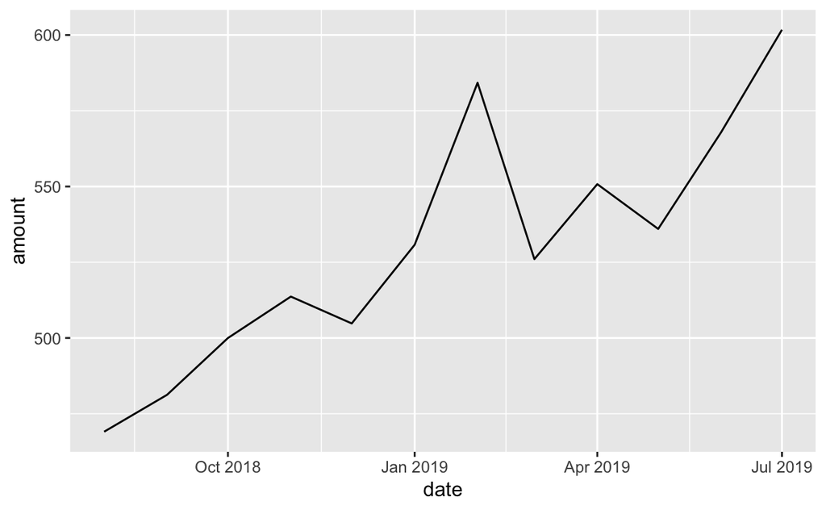

```r
qb_monthly_sales %>%
  filter(cashflow == "Kwikbit Unit 1 Sales") %>%
  ggplot() +
    aes(x = date, y = amount) +
    geom_line()
```

## 2.2.2 - prettify plot

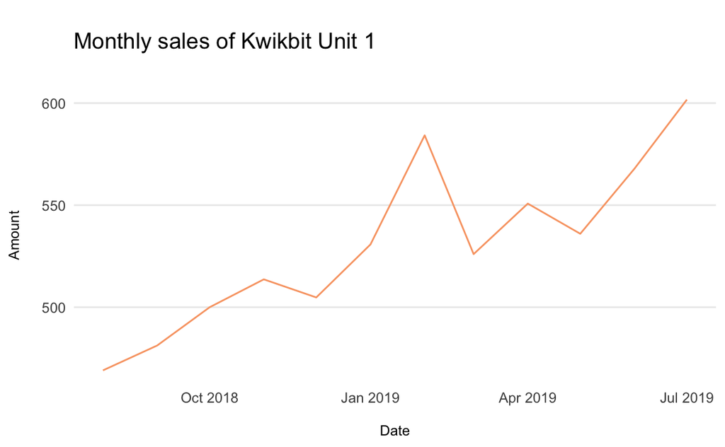

```r
#min_date <- as.date(paste(min(qb_monthly_sales$date)
#max_date <- max(qb_monthly_sales$date)

qb_monthly_sales %>%
  filter(cashflow == "Kwikbit Unit 1 Sales") %>%
  ggplot() +
    aes(x = date, y = amount) +
    geom_line(colour = sample(col_scheme,1)) +
  labs(
    x = "\nDate",
    y = "Amount\n",
    title = "\nMonthly sales of Kwikbit Unit 1\n"
  ) +
  #scale_x_date(
    #date_labels = "%m%y",
    #breaks = min(qb_monthly_sales$date),max(qb_monthly_sales$date),
   # date_breaks = "3 months") +
    theme_kwikbit()
```

## 2.1.3 - make plot

Make a line chart showing monthly revenue and costs over the last year. This data is also in qb_monthly_sales.

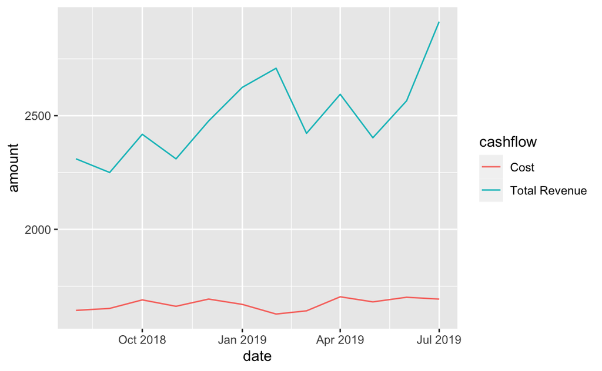

```r
qb_monthly_sales %>%
  filter(cashflow != "Kwikbit Unit 1 Sales") %>%
  ggplot() +
    aes(x = date, y = amount, colour = cashflow) +
    geom_line()
```

## 2.2.3 - prettify plot

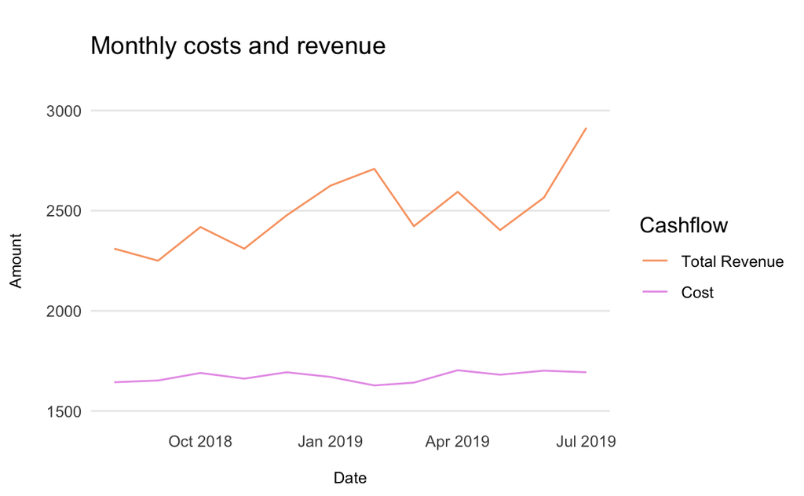

```r
qb_monthly_sales %>%
  filter(cashflow != "Kwikbit Unit 1 Sales") %>%
  ggplot() +
    aes(x = date, y = amount, colour = cashflow) +
    geom_line() +
  scale_colour_manual(values = c("Total Revenue" = "#F9A472","Cost" = "#E89FE9")) +
  labs(
    x = "\nDate",
    y = "Amount\n",
    title = "\nMonthly costs and revenue\n",
    colour = "Cashflow"
  ) +
  scale_y_continuous(
    limits = c(1500,3000)
    ) +
  theme_kwikbit()
```

## 2.1.4 - make plot

Show annual sales of personal fitness trackers over the last 5 years broken down by company as a ribbon plot (use geom_area). This data is in qb_competitors.

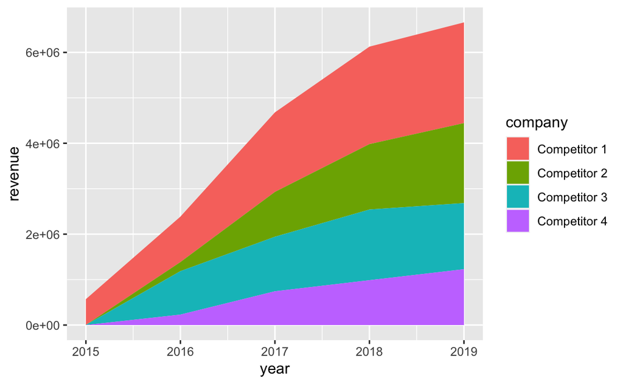

```r
ggplot(qb_competitors) +
  aes(x = year, y = revenue, fill = company) +
  geom_area()
```

## 2.2.4 - prettify plot

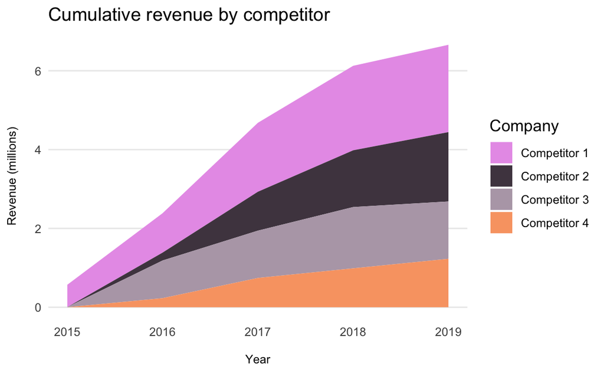

```r
qb_competitors %>%
  mutate(revenue_mil = (revenue / 1000000)) %>%
  ggplot() +
    aes(x = year, y = revenue_mil, fill = company) +
    geom_area() +
    scale_fill_manual(values = c(col_scheme)) +
    scale_y_continuous(labels = scales::comma) +
    labs(
      x = "\nYear",
      y = "Revenue (millions)\n",
      title = "Cumulative revenue by competitor",
      fill = "Company"
    ) +
    theme_kwikbit()
```

## 2.1.5 - make plot

Now show the sales from the four competitors as a line graph. Include an extra layer that shows the data points used to make the lines.

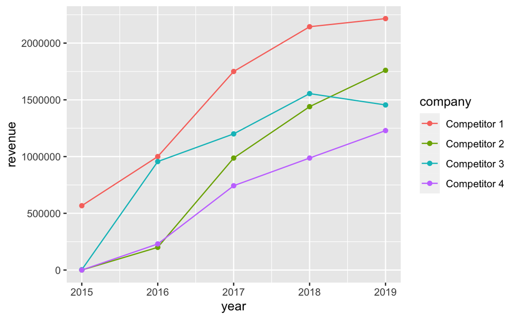

```r
ggplot(qb_competitors) +
  aes(x = year, y = revenue, colour = company) +
  geom_line() +
  geom_point()
```

## 2.2.5 - prettify plot

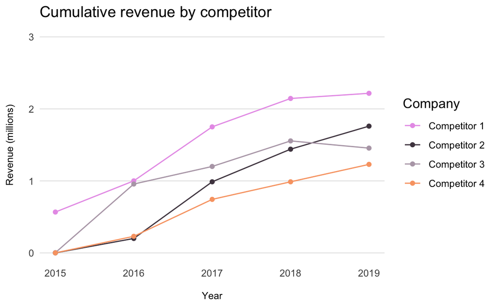

```r
qb_competitors %>%
  mutate(revenue_mil = (revenue / 1000000)) %>%
  ggplot() +
  aes(x = year, y = revenue_mil, colour = company) +
  geom_line() +
  geom_point() +
  scale_y_continuous(limits = c(0,3)) +
  scale_colour_manual(values = c(col_scheme)) +
  labs(
    x = "\nYear",
    y = "Revenue (millions)\n",
    title = "Cumulative revenue by competitor",
    colour = "Company"
  ) +
  theme_kwikbit()
```

## 2.1.6 - make plot

Now the company wants to compare the number of steps that their device counts vs. their competitors. Make a line graph of the number of steps throughout time, and use faceting to compare between companies and people. The data for this is in qb_device_data.

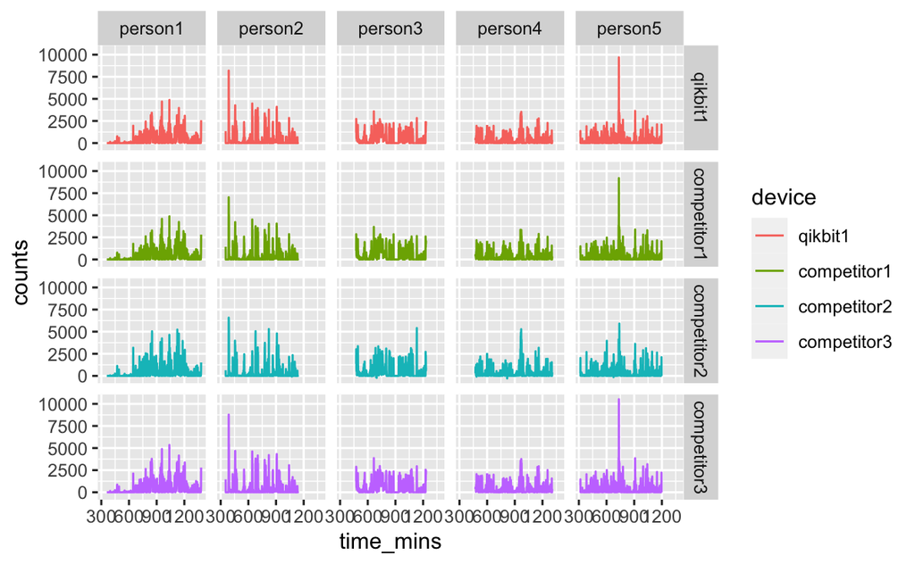

```r
qb_device_data %>%
  mutate(time_mins = (60*hours)+mins) %>%
  ggplot() +
    aes(x = time_mins, y = counts, colour = device) +
    geom_line() +
  facet_grid(device ~ id)
```

## 2.2.6 - prettify plot

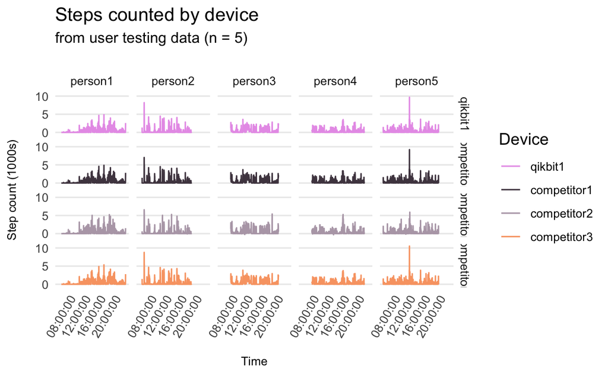

```r
qb_device_data %>%
  mutate(time_mins = 60*((60*hours)+mins)) %>%
  mutate(count_k = (counts/1000)) %>%
  mutate(time = hms::as_hms(time_mins)) %>%
    ggplot() +
      aes(x = time, y = count_k, colour = device) +
      geom_line() +
      scale_colour_manual(values = c(col_scheme)) +
      scale_y_continuous(breaks = c(0,5,10,15)) +
      labs(
        x = "\nTime",
        y = "Step count (1000s)\n",
        title = "Steps counted by device",
        subtitle = "from user testing data (n = 5)\n",
        colour = "Device"
      ) +
      facet_grid(device ~ id) +
      theme_kwikbit() +
      theme(axis.text.x = element_text(angle = 60, hjust = 1))
```